# Bayesian multilevel models

Jörn Alexander Quent

11 November 2019

# Aim of talk

- Showing how easy it is to implement prober Bayesian mutlilevel models,
- but making you vary of some of the dangers.
- Analysising RT data with [`BRMS`](https://cran.r-project.org/web/packages/brms/index.html) package.

# Example data

- Stroop task:
  - 26 participants,
  - On average 191 trials per participant,
  - Congruency: 4 incongruent vs 4 neutral words.
  - DV: Reaction time.
- We want to accurately account for participant and stimulus variation.
  - Therefore we use mutlilevel approach that includes stimulus and participants as crossed random effects (Judd et al., 2012).

$$log(RT) \sim congruency + (congruency | subNum) + (1 | stimulus)$$

# Data preparation

```r
load("exampleData/stroopData.RData")
```

After loading, we transform from raw RT data to log(RT),

```r
stroopData$logRT <- log(stroopData$RT)
```

and then we scale the data to have a mean of 0 and a SD of 1.

```r
stroopData$s_logRT <- scale(stroopData$logRT)
```

This important because parameters (e.g. $\beta$-values) and hence priors depend on the scale of the data.

# BRMS vs. lme4

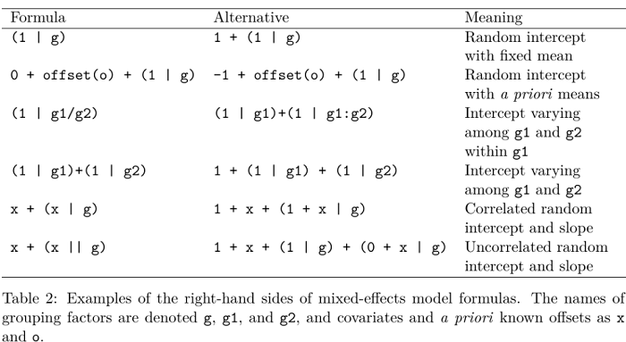

- BRMS use the same syntax as `lme4`.
- Also, most functions we know from `lme4` still work, e.g. `ranef()`, `fixef()` and `coef()`.
- When you get it to work, it’s very flexible.

# lmer results

```r
library(lme4)
logRT_lme4_m1 <- lmer(s_logRT ~ congruency + (congruency | subNum) + (1 | stimulus),data = stroopData)
summary(logRT_lme4_m1)
```

```
## Linear mixed model fit by REML ['lmerMod']
## Formula: s_logRT ~ congruency + (congruency | subNum) + (1 | stimulus)
##    Data: stroopData
##
## REML criterion at convergence: 13072.3
##
## Scaled residuals:
##     Min      1Q  Median      3Q     Max
## -3.7462 -0.6468  0.0200  0.6834  2.7604
##
## Random effects:
##  Groups   Name              Variance Std.Dev. Corr
##  subNum   (Intercept)       0.263724 0.51354
##           congruencyneutral 0.056390 0.23747  -0.70
##  stimulus (Intercept)       0.001425 0.03776
##  Residual                   0.790469 0.88908
## Number of obs: 4968, groups:  subNum, 26; stimulus, 8
##
## Fixed effects:
##                   Estimate Std. Error t value
## (Intercept)        0.11912    0.10403   1.145
## congruencyneutral -0.22763    0.05933  -3.837
##
## Correlation of Fixed Effects:
##             (Intr)
## cngrncyntrl -0.644
```

# Our BRMS model

To run our model we first set priors for our population-level effects:

```r
priors <- c(prior(normal(0, 1), class = "Intercept"),
            prior(normal(0, 1), class = "b"))
```

Since the DV has mean of 0 and SD = 1, $\beta$-values > 1 are very unlikely.

```r
logRT_bayes_m1 <- brm(s_logRT ~ congruency + (congruency | subNum) + (1 | stimulus),
                      save_all_pars = TRUE,
                      sample_prior = TRUE,
                      data = stroopData,
                      cores = 8,
                      chains = 8,
                      iter = 3000,
                      prior = priors)
```

To fit our model, we use the same syntax that we would used in `lme4`. To get stable estimates, we set a relatively high number of `iter` per Markov-chain.

# Our BRMS model

```r
summary(logRT_model)
```

```
##  Family: gaussian
##   Links: mu = identity; sigma = identity
## Formula: s_logRT ~ congruency + (congruency | subNum) + (1 | stimulus)
##    Data: stroopData (Number of observations: 4968)
## Samples: 8 chains, each with iter = 3000; warmup = 1500; thin = 1;
##          total post-warmup samples = 12000
##
## Group-Level Effects:
## ~stimulus (Number of levels: 8)
##               Estimate Est.Error l-95% CI u-95% CI Eff.Sample Rhat
## sd(Intercept)     0.05      0.03     0.00     0.12       3744 1.00
##
## ~subNum (Number of levels: 26)
##                                  Estimate Est.Error l-95% CI u-95% CI
## sd(Intercept)                        0.54      0.09     0.40     0.74
## sd(congruencyneutral)                0.25      0.05     0.17     0.36
## cor(Intercept,congruencyneutral)    -0.65      0.14    -0.87    -0.33
##                                  Eff.Sample Rhat
## sd(Intercept)                          2328 1.00
## sd(congruencyneutral)                  3953 1.00
## cor(Intercept,congruencyneutral)       6684 1.00
##
## Population-Level Effects:
##                   Estimate Est.Error l-95% CI u-95% CI Eff.Sample Rhat
## Intercept             0.12      0.11    -0.11     0.34       1938 1.00
## congruencyneutral    -0.23      0.07    -0.36    -0.09       4366 1.00
##
## Family Specific Parameters:
##       Estimate Est.Error l-95% CI u-95% CI Eff.Sample Rhat
## sigma     0.89      0.01     0.87     0.91      15610 1.00
##
## Samples were drawn using sampling(NUTS). For each parameter, Eff.Sample
## is a crude measure of effective sample size, and Rhat is the potential
## scale reduction factor on split chains (at convergence, Rhat = 1).
```

# Fixed effects

To extract our population-level effects we can just use:

```r
fixef(logRT_model)
```

```
##                     Estimate  Est.Error       Q2.5       Q97.5
## Intercept          0.1180950 0.11250116 -0.1051123  0.33898887
## congruencyneutral -0.2252597 0.06881087 -0.3613557 -0.08636003
```

# Extracting random effects

```r
ranef_logRT_model <- coef(logRT_model)
```

or for the specific coefficents:

```r
coef_logRT_model <- coef(logRT_model)
head(coef_logRT_model$subNum[,,'congruencyneutral'])
```

```
##      Estimate Est.Error       Q2.5        Q97.5
## 1 -0.16427234 0.1199968 -0.3952480  0.072046181
## 2 -0.22350604 0.1219962 -0.4598135  0.017713133
## 3 -0.08290738 0.1137104 -0.3034358  0.142858286
## 4 -0.17380949 0.1199388 -0.4047122  0.062053284
## 5  0.01602785 0.1191119 -0.2172137  0.252323935
## 6 -0.23197516 0.1185006 -0.4685188 -0.002599057
```

Above you see the estimated slope for the first 6 participants.

# Visualisation of results

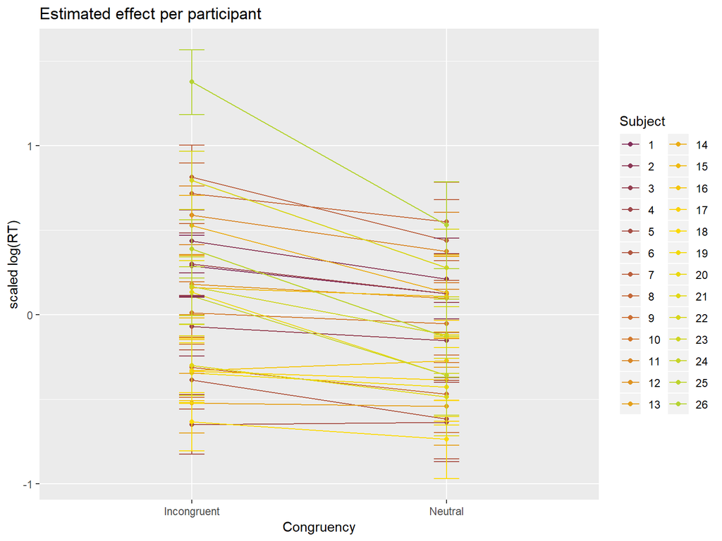

# Visualisation of results

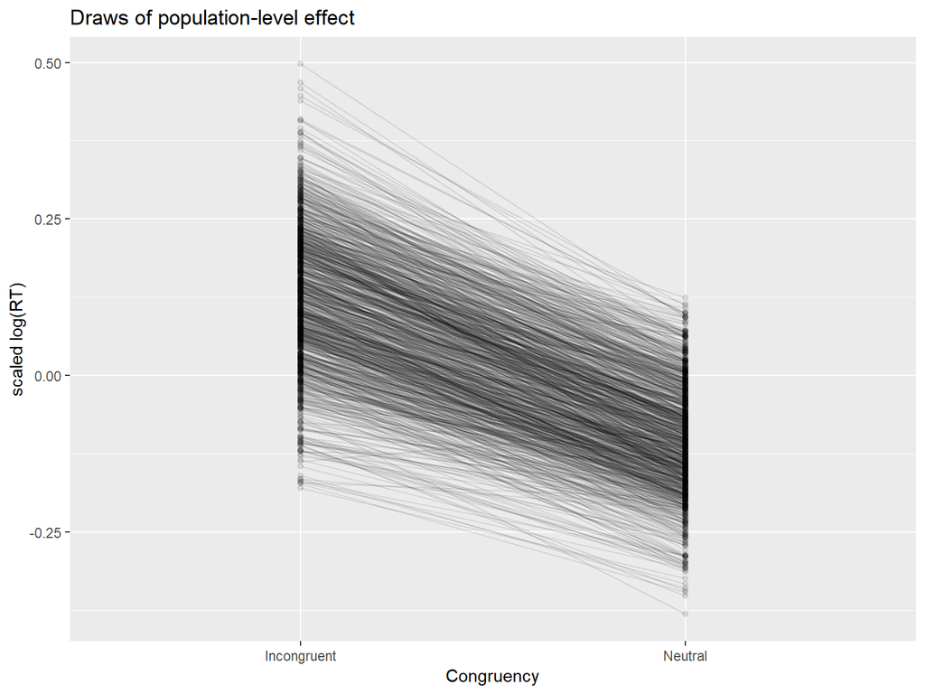

# What so special about Bayesian linear models

Instead of point estimates for $\beta_{0ij}$ and $\beta_{1ij}$, we get *posterior* distributions (`iter/2` x `chains` = 12000 samples):

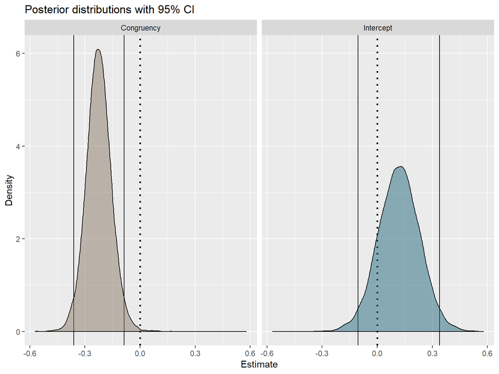

“In Bayesian statistics, a **credible interval** is an interval within which an unobserved parameter value falls with a particular probability” (source: [wiki](https://en.wikipedia.org/wiki/Credible_interval)).

> Evidence in favour of effect if no overlap with zero.

# Bayesian multilevel models

For instance, let $\alpha$ be the common intercept and $\boldsymbol{\beta}$ be the common coefficients while $a_j$ is the deviation from the common intercept in the $j$-th group and $\mathbf{b}_j$ is the deviation from the common coefficients. Write the model as:
$$y_{ij} = \alpha + \sum_{k = 1}^K \beta_k x_{ik}+\underbrace{a_j + \sum_{k = 1}^K b_{jk} x_{ik} +\overbrace{\boldsymbol{\epsilon}}^{\mbox{Bayesian error}}}_{\mbox{Frequentist error}}$$

- Frequentists assume that $a_j$ and $b_j$ deviate from the common parameters according to a (multivariate) normal distribution, whose (co)variances are common parameters to be estimated.
- To Frequentists, $a_j$ and $b_j$ are not parameters because parameters must remained fixed in repeated sampling of observations from some population.
- Since $a_j$ and $b_j$ are not parameters, they can’t be “estimated” only “predicted”.
- Since $a_j$ and $b_j$ aren’t estimated, they must be integrated out of the likelihood function, leaving an integrated likelihood function of the common parameters.

Ben Goodrich, [Cambridge 2019](https://mc-stan.org/workshops/stancon2019_hierarchical/)

# Bayesian multilevel models

- Provide standard error and CI for parameters:
  - Random effects,
  - Family parameters.
  - If you still wand standard error from `lme` use `arm` package (e.g. `se.ranef`).
- Allow use of prior information.
- According to [Andrew Gelman](https://statmodeling.stat.columbia.edu/2007/09/06/classical_or_ba/):
  - Bayesian model work best if group-level variance is hard to estimate
  - And number of groups in small.

# Bayesian inference

- We can make inference about effects with
  - Examing credible intervals and
  - Quantify evidence by using Bayes factors.

# Bayes factors

Bayes factors are calculated from from Marginal Likelihoods:
$$BF_{10} =\frac{likelihood\ of\ data\ given\ H_1}{likelihood\ of\ data\ given\ H_o} = \frac{P(D|H_1)}{P(D|H_0)}$$
In our example we get get $BF_{10}$ by fitting a **null model** that doesn’t include our effect of interest:

```r
logRT_bayes_m0 <- brm(s_logRT ~ 1 + (congruency | subNum) + (1 | stimulus),
                   save_all_pars = TRUE,
                   sample_prior = TRUE,
                   data = stroopData,
                   cores = 8,
                   chains = 8,
                   iter = 3000,
                   prior = priors)
```

for our null model we only need a prior for the Intercept.

```r
priors <- c(prior(normal(0, 1), class = "Intercept"))
```

# Bayes factors

We then use

```r
bf <- bayes_factor(logRT_bayes_m1, logRT_bayes_m0)
```

and get $BF_{10}$ = 7.83, which is moderate evidence for $H_1$. We get similar results with `lme4`:

```r
logRT_lme4_m0 <- lmer(s_logRT ~ 1 + (congruency | subNum) + (1 | stimulus),data = stroopData)
anova(logRT_lme4_m0, logRT_lme4_m1)
```

```
## Data: stroopData
## Models:
## logRT_lme4_m0: s_logRT ~ 1 + (congruency | subNum) + (1 | stimulus)
## logRT_lme4_m1: s_logRT ~ congruency + (congruency | subNum) + (1 | stimulus)
##               Df   AIC   BIC  logLik deviance  Chisq Chi Df Pr(>Chisq)
## logRT_lme4_m0  6 13089 13128 -6538.3    13077
## logRT_lme4_m1  7 13079 13125 -6532.6    13065 11.479      1  0.0007037 ***
## ---
## Signif. codes:  0 '***' 0.001 '**' 0.01 '*' 0.05 '.' 0.1 ' ' 1
```

# Bayes factors

Another way calcualte the BF is the Savage-Dickey ratio that is
$$BF_{10} = \frac{p(D|H_{1})}{p(D|H_{0})} = \frac{p(\theta = 0|H_{1})}{p(\theta = 0|D,H_{0})}$$

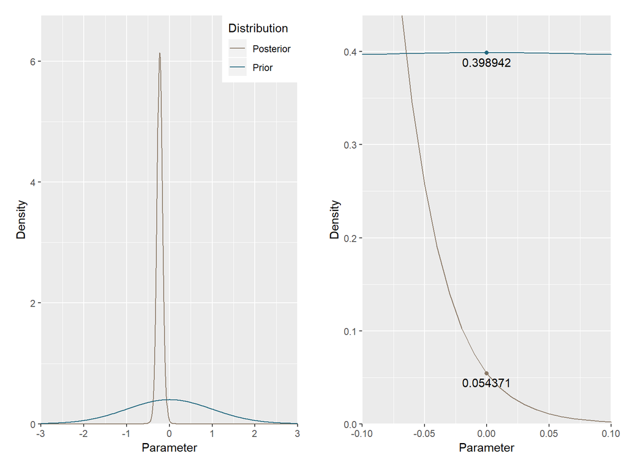

# Bayes factors

We calculate the Savage-Dickey ratio following Wagenmakers et al. (2010)

```r
library(polspline)

postSamples   <- posterior_samples(logRT_model)
fit.posterior <- logspline(postSamples$b_congruencyneutral)
posterior     <- dlogspline(0, fit.posterior)
prior         <- dnorm(0, 0, 1)
BF10          <- prior/posterior
```

and get $BF_{10}$ = 7.34.

- The Savage-Dickey ratio also allows order restricted hypoheses: $H_0: \beta = 0 \lor H_1: \beta > 0$ (see Wagenmakers et al. (2010)).

# Bayes factors

For this we can use the `bmrs` function `hypothesis()`. Then,

```r
hypothesis(logRT_model, "congruencyneutral = 0")
```

we get a $BF_{10}$ = 7.98.

# Ignoring participant and stimulus variation

```r
library(BayesFactor)
stroopData_agg <- ddply(stroopData, c('subNum', 'congruency'), summarise, RT = mean(RT))
anovaBF(RT ~ congruency + subNum,  data = stroopData_agg, whichRandom = c('subNum'))
```

```
## Bayes factor analysis
## --------------
## [1] congruency + subNum : 63.82477 ±0.8%
##
## Against denominator:
##   RT ~ subNum
## ---
## Bayes factor type: BFlinearModel, JZS
```

# Summary

- If you can, don’t average across trials (see Judd et al.. 2012)!
- There various ways to calculate Bayes factors. A nice comparison can be found here: https://rpubs.com/lindeloev/bayes_factors.
- Model fitting ins BRMS takes more time, but also provides more possibilities.
- Added complexity with priors, requires you to be more careful.
- **Important**: Right scale of priors and variables are important.
  - **Inappropriate priors lead to completely wrong Bayes factors**.
- Pay attention to **warnings**:
  - No convergence and divergernces are a problem.
  - $\hat{R}$ must not be higher than 1.
  - Also, do prober posterior checks for instance with `pp_check()`

# References

- Judd, C. M., Westfall, J., & Kenny, D. A. (2012). Treating stimuli as a random factor in social psychology: A new and comprehensive solution to a pervasive but largely ignored problem. Journal of Personality and Social Psychology, 103(1), 54–69. https://doi.org/10.1037/a0028347
- Wagenmakers, E.-J., Lodewyckx, T., Kuriyal, H., & Grasman, R. (2010). Bayesian hypothesis testing for psychologists: A tutorial on the Savage–Dickey method. Cognitive Psychology, 60(3), 158–189. https://doi.org/https://doi.org/10.1016/j.cogpsych.2009.12.001
- Bürkner P (2017). “brms: An R Package for Bayesian Multilevel Models Using Stan.” Journal of Statistical Software, 80(1), 1–28. doi: 10.18637/jss.v080.i01.
- Bürkner P (2018). “Advanced Bayesian Multilevel Modeling with the R Package brms.” The R Journal, 10(1), 395–411. doi: 10.32614/RJ-2018-017.

# Become Bayesian with

*[Introduction to Bayesian Inference for Psychology](https://link.springer.com/article/10.3758/s13423-017-1262-3)* from Etz and Vandekerckhove (2018) and if you want a book

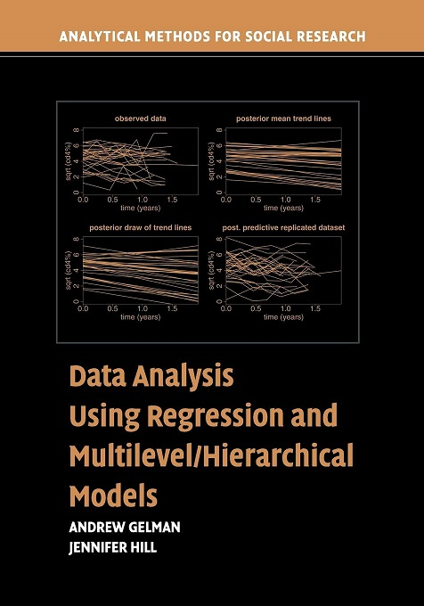